# Leydet Lab04 - Modeling II

David Leydet

2022-09-14

# GEOG6000 - Methods of Data Analysis

```r
setwd("~/Desktop/University of Utah PhD /Course Work/Fall 2022 Semester/GEOG6000_Data Analysis/lab04") ##Set working directory
```

# Initial Scripting Practice Exercise

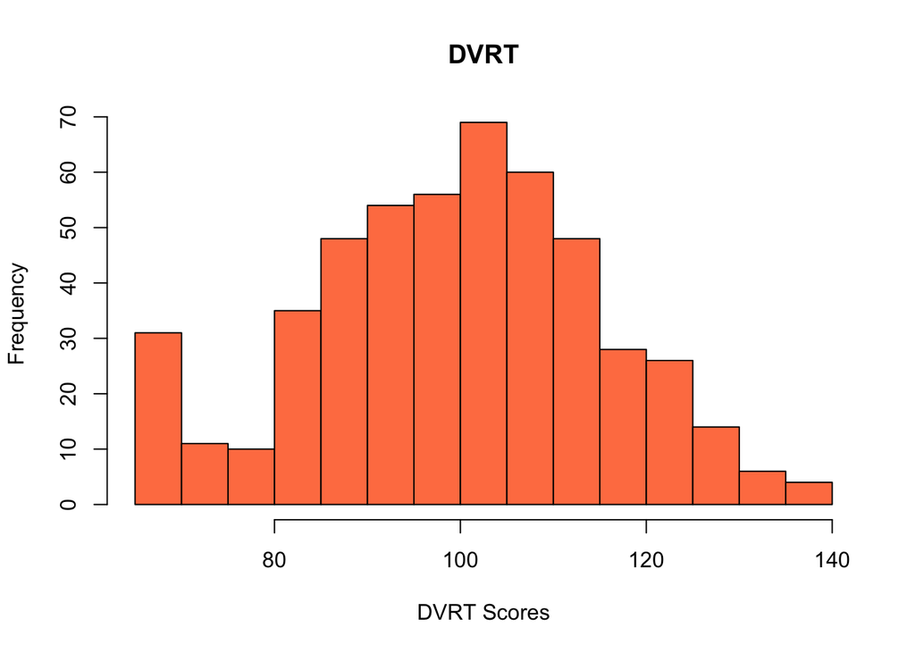

```r
irished = read.csv("../datafiles/irished.csv")
irished$sex = factor(irished$sex,
                     levels = c(1, 2),
                     labels = c("Male", "Female")) ##changed 1 and 2 to male and female

hist(irished$DVRT,
     main = "DVRT",
     breaks = 20,
     xlab = "DVRT Scores",
     col = "coral")
```

```r
##See the lab for saving this as a script then running it using the source() function
```

# Programming Flow

```r
for (i in 1:10) { print(i) } #Simple loop - runs ten times printing "i"
```

```
## [1] 1
## [1] 2
## [1] 3
## [1] 4
## [1] 5
## [1] 6
## [1] 7
## [1] 8
## [1] 9
## [1] 10
```

```r
source("../datafiles/cointoss.r") #Coin toss loop see the script for the syntax and functions
```

```
## [1] "Heads: 47"
## [1] "Tails: 53"
```

```r
#Question on the loop syntax specifically the "runif" and "if" statement
```

# Creating your own functions

```r
mySD = function (x) { sqrt (var(x)) } #Creating a function to calculate SD
mySD(irished$DVRT) #Calculates the same as the built in R function "sd"
```

```
## [1] 15.45635
```

# Multiple Linear Regression

```r
runoff = read.csv("../datafiles/SoCal_Runoff.csv")

summary(runoff) #Basic summary statistics for the datafile
```

```
##       Year           AP1              AP2              AP3
##  Min.   :1948   Min.   : 2.700   Min.   : 1.450   Min.   : 1.77
##  1st Qu.:1958   1st Qu.: 4.975   1st Qu.: 3.390   1st Qu.: 3.36
##  Median :1969   Median : 7.080   Median : 4.460   Median : 4.62
##  Mean   :1969   Mean   : 7.323   Mean   : 4.652   Mean   : 4.93
##  3rd Qu.:1980   3rd Qu.: 9.115   3rd Qu.: 5.685   3rd Qu.: 5.83
##  Max.   :1990   Max.   :18.080   Max.   :11.960   Max.   :13.02
##       OP1              OP2              OP3             RUNOFF
##  Min.   : 4.050   Min.   : 4.350   Min.   : 4.600   Min.   : 41785
##  1st Qu.: 7.975   1st Qu.: 7.875   1st Qu.: 8.705   1st Qu.: 59857
##  Median : 9.550   Median :11.110   Median :12.140   Median : 69177
##  Mean   :12.836   Mean   :12.002   Mean   :13.522   Mean   : 77756
##  3rd Qu.:16.545   3rd Qu.:14.975   3rd Qu.:16.920   3rd Qu.: 92206
##  Max.   :43.370   Max.   :24.850   Max.   :33.070   Max.   :146345
```

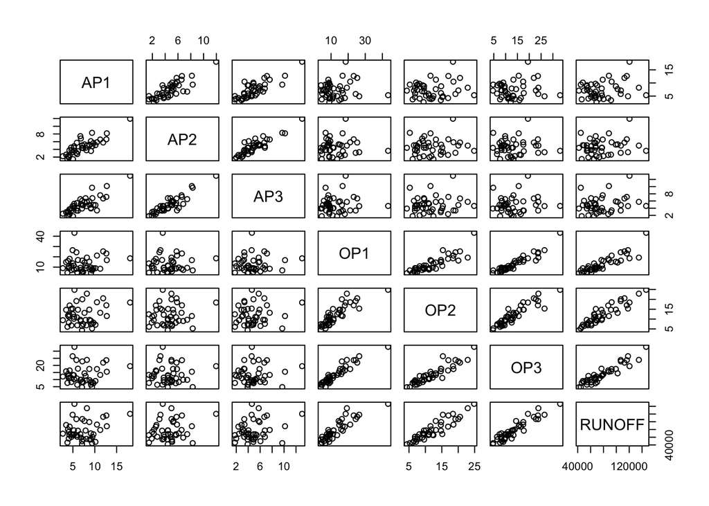

```r
pairs(runoff[ , -1]) #Useful for looking at the correlation between variables
```

```r
#[ , -1] syntax subtracts the first column from the plot
```

# Builing and Examining the Full Model

```r
runoff2 = runoff[ , -1] #*NOTE RUNNING THIS MULTIPLE TIMES WILL CONTINUE TO TAKE COLUMNS OUT!*
runoff2.mod1 = lm(RUNOFF ~ . , data = runoff2) # . denotes full model with all the variables
summary(runoff2.mod1)
```

```
##
## Call:
## lm(formula = RUNOFF ~ ., data = runoff2)
##
## Residuals:
##    Min     1Q Median     3Q    Max
## -12690  -4936  -1424   4173  18542
##
## Coefficients:
##             Estimate Std. Error t value Pr(>|t|)
## (Intercept) 15944.67    4099.80   3.889 0.000416 ***
## AP1           -12.77     708.89  -0.018 0.985725
## AP2          -664.41    1522.89  -0.436 0.665237
## AP3          2270.68    1341.29   1.693 0.099112 .
## OP1            69.70     461.69   0.151 0.880839
## OP2          1916.45     641.36   2.988 0.005031 **
## OP3          2211.58     752.69   2.938 0.005729 **
## ---
## Signif. codes:  0 '***' 0.001 '**' 0.01 '*' 0.05 '.' 0.1 ' ' 1
##
## Residual standard error: 7557 on 36 degrees of freedom
## Multiple R-squared:  0.9248, Adjusted R-squared:  0.9123
## F-statistic: 73.82 on 6 and 36 DF,  p-value: < 2.2e-16
```

```r
anova(runoff2.mod1)
```

```
## Analysis of Variance Table
##
## Response: RUNOFF
##           Df     Sum Sq    Mean Sq  F value    Pr(>F)
## AP1        1 1.5567e+09 1.5567e+09  27.2595 7.634e-06 ***
## AP2        1 1.7427e+07 1.7427e+07   0.3052  0.584071
## AP3        1 6.6126e+08 6.6126e+08  11.5794  0.001649 **
## OP1        1 1.9991e+10 1.9991e+10 350.0595 < 2.2e-16 ***
## OP2        1 2.5762e+09 2.5762e+09  45.1115 7.752e-08 ***
## OP3        1 4.9301e+08 4.9301e+08   8.6332  0.005729 **
## Residuals 36 2.0558e+09 5.7106e+07
## ---
## Signif. codes:  0 '***' 0.001 '**' 0.01 '*' 0.05 '.' 0.1 ' ' 1
```

# Variance Inflation

Correlation Matrix

```r
cor(runoff2)
```

```
##              AP1        AP2        AP3        OP1       OP2        OP3
## AP1    1.0000000 0.82768637 0.81607595 0.12238567 0.1544155 0.10754212
## AP2    0.8276864 1.00000000 0.90030474 0.03954211 0.1056396 0.02961175
## AP3    0.8160760 0.90030474 1.00000000 0.09344773 0.1063836 0.10058669
## OP1    0.1223857 0.03954211 0.09344773 1.00000000 0.8647073 0.94334741
## OP2    0.1544155 0.10563959 0.10638359 0.86470733 1.0000000 0.91914467
## OP3    0.1075421 0.02961175 0.10058669 0.94334741 0.9191447 1.00000000
## RUNOFF 0.2385695 0.18329499 0.24934094 0.88574778 0.9196270 0.93843604
##           RUNOFF
## AP1    0.2385695
## AP2    0.1832950
## AP3    0.2493409
## OP1    0.8857478
## OP2    0.9196270
## OP3    0.9384360
## RUNOFF 1.0000000
```

## Correlation Plot Practice

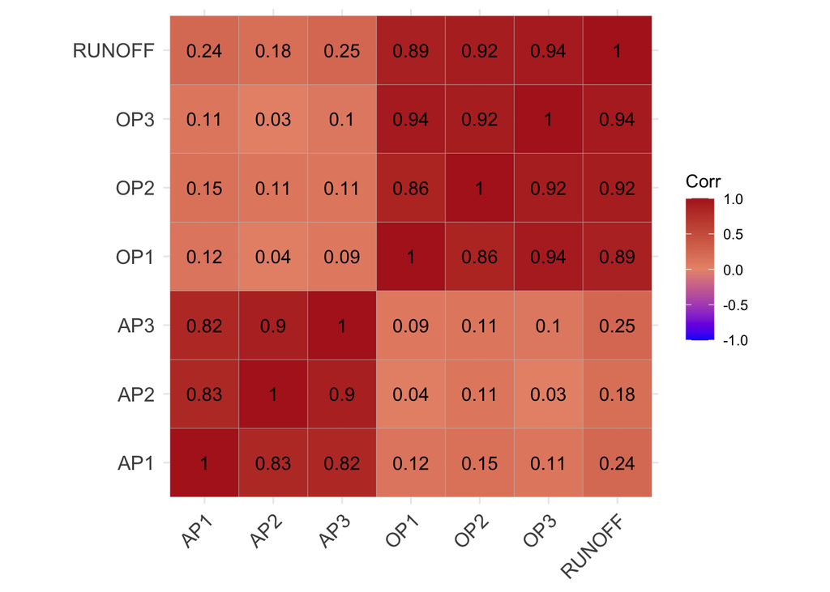

```r
library(ggplot2)
library(ggcorrplot) #Load the correlation plot package

ggcorrplot(cor(runoff2),
           method = "square",
           type = "full",
           lab = TRUE,
           colors = c("blue", "darksalmon", "firebrick"))
```

## VIF Function

```r
library(car)
vif(runoff2.mod1) ##Remember values over 5 indicate collinearity and values over 10 mean it is definitely has a collinear relationship!
```

```
##       AP1       AP2       AP3       OP1       OP2       OP3
##  3.546344  7.183798  6.748004  9.266088  7.648712 16.970457
```

## Creating a second model

This aids to reduce the effect of collinear variables on the model

```r
runoff2.mod2 = lm(RUNOFF ~ AP3 + OP3, data = runoff2)

summary(runoff2.mod2)
```

```
##
## Call:
## lm(formula = RUNOFF ~ AP3 + OP3, data = runoff2)
##
## Residuals:
##      Min       1Q   Median       3Q      Max
## -13335.8  -5893.2   -171.8   4219.5  19500.2
##
## Coefficients:
##             Estimate Std. Error t value Pr(>|t|)
## (Intercept)  19144.9     3812.0   5.022  1.1e-05 ***
## AP3           1768.8      553.7   3.194  0.00273 **
## OP3           3689.5      196.0  18.829  < 2e-16 ***
## ---
## Signif. codes:  0 '***' 0.001 '**' 0.01 '*' 0.05 '.' 0.1 ' ' 1
##
## Residual standard error: 8063 on 40 degrees of freedom
## Multiple R-squared:  0.9049, Adjusted R-squared:  0.9002
## F-statistic: 190.3 on 2 and 40 DF,  p-value: < 2.2e-16
```

# Comparing Models

Based on the *F*-statistic and the degrees of freedom, it appears that model 2 (Runoff2.mod2) is the better model, despite having a slightly lower $r^2$ value.

```r
anova(runoff2.mod1, runoff2.mod2)
```

```
## Analysis of Variance Table
##
## Model 1: RUNOFF ~ AP1 + AP2 + AP3 + OP1 + OP2 + OP3
## Model 2: RUNOFF ~ AP3 + OP3
##   Res.Df        RSS Df  Sum of Sq      F  Pr(>F)
## 1     36 2055830733
## 2     40 2600641788 -4 -544811055 2.3851 0.06933 .
## ---
## Signif. codes:  0 '***' 0.001 '**' 0.01 '*' 0.05 '.' 0.1 ' ' 1
```

- Based on this test, we would accept the null hypothesis that the full model is **NOT** better than the simple, or subset, model.

# Automatic Variable Selection

```r
#Full Model is runoff2.mod1

runoff2.mod0 = lm(RUNOFF ~ 1, data = runoff2) #Null/initial model using one variable. This will be used to stepwise through possible combinations to test which combination of variables fits the best.

step(runoff2.mod0, scope = formula(runoff2.mod1))
```

```
## Start:  AIC=873.65
## RUNOFF ~ 1
##
##        Df  Sum of Sq        RSS    AIC
## + OP3   1 2.4087e+10 3.2640e+09 784.24
## + OP2   1 2.3131e+10 4.2199e+09 795.28
## + OP1   1 2.1458e+10 5.8928e+09 809.64
## + AP3   1 1.7004e+09 2.5651e+10 872.89
## + AP1   1 1.5567e+09 2.5794e+10 873.13
## <none>               2.7351e+10 873.65
## + AP2   1 9.1891e+08 2.6432e+10 874.18
##
## Step:  AIC=784.24
## RUNOFF ~ OP3
##
##        Df  Sum of Sq        RSS    AIC
## + AP3   1 6.6337e+08 2.6006e+09 776.47
## + AP2   1 6.6199e+08 2.6020e+09 776.49
## + OP2   1 5.7405e+08 2.6900e+09 777.92
## + AP1   1 5.2428e+08 2.7397e+09 778.71
## <none>               3.2640e+09 784.24
## + OP1   1 5.6424e+04 3.2640e+09 786.24
## - OP3   1 2.4087e+10 2.7351e+10 873.65
##
## Step:  AIC=776.47
## RUNOFF ~ OP3 + AP3
##
##        Df  Sum of Sq        RSS    AIC
## + OP2   1 5.3169e+08 2.0689e+09 768.63
## <none>               2.6006e+09 776.47
## + AP2   1 3.3349e+07 2.5673e+09 777.91
## + AP1   1 1.1041e+07 2.5896e+09 778.28
## + OP1   1 1.2245e+05 2.6005e+09 778.46
## - AP3   1 6.6337e+08 3.2640e+09 784.24
## - OP3   1 2.3050e+10 2.5651e+10 872.89
##
## Step:  AIC=768.63
## RUNOFF ~ OP3 + AP3 + OP2
##
##        Df  Sum of Sq        RSS    AIC
## <none>               2068947585 768.63
## + AP2   1   11814207 2057133378 770.39
## + AP1   1    1410311 2067537274 770.60
## + OP1   1     583748 2068363837 770.62
## - OP2   1  531694203 2600641788 776.47
## - AP3   1  621012173 2689959758 777.92
## - OP3   1 1515918540 3584866125 790.27
```

```
##
## Call:
## lm(formula = RUNOFF ~ OP3 + AP3 + OP2, data = runoff2)
##
## Coefficients:
## (Intercept)          OP3          AP3          OP2
##       15425         2390         1712         1797
```

- The final, lowest, AIC is 768.63. From step 1 to step 2 the AIC drops approximately 90. On subsequent steps the drop is less drastic at about 8.
- The selected model is pretty close to the reduced model we used earlier. It adds OP2 which brings the AIC down about 8 from our reduced model.

# Extending the basic model

```r
kidiq = read.csv("../datafiles/kidiq.csv")
str(kidiq)
```

```
## 'data.frame':    434 obs. of  5 variables:
##  $ kid.score: int  65 98 85 83 115 98 69 106 102 95 ...
##  $ mom.hs   : int  1 1 1 1 1 0 1 1 1 1 ...
##  $ mom.iq   : num  121.1 89.4 115.4 99.4 92.7 ...
##  $ mom.work : int  4 4 4 3 4 1 4 3 1 1 ...
##  $ mom.age  : int  27 25 27 25 27 18 20 23 24 19 ...
```

```r
summary(kidiq)
```

```
##    kid.score         mom.hs           mom.iq          mom.work
##  Min.   : 20.0   Min.   :0.0000   Min.   : 71.04   Min.   :1.000
##  1st Qu.: 74.0   1st Qu.:1.0000   1st Qu.: 88.66   1st Qu.:2.000
##  Median : 90.0   Median :1.0000   Median : 97.92   Median :3.000
##  Mean   : 86.8   Mean   :0.7857   Mean   :100.00   Mean   :2.896
##  3rd Qu.:102.0   3rd Qu.:1.0000   3rd Qu.:110.27   3rd Qu.:4.000
##  Max.   :144.0   Max.   :1.0000   Max.   :138.89   Max.   :4.000
##     mom.age
##  Min.   :17.00
##  1st Qu.:21.00
##  Median :23.00
##  Mean   :22.79
##  3rd Qu.:25.00
##  Max.   :29.00
```

```r
kidiq.lm1 = lm(kid.score ~ mom.hs, data = kidiq) #simple linear model of the kid's IQ score as a function of her/his mother's attendance to high school. R automatically treats binary values, 0/1, as a dummy variable

summary(kidiq.lm1)
```

```
##
## Call:
## lm(formula = kid.score ~ mom.hs, data = kidiq)
##
## Residuals:
##    Min     1Q Median     3Q    Max
## -57.55 -13.32   2.68  14.68  58.45
##
## Coefficients:
##             Estimate Std. Error t value Pr(>|t|)
## (Intercept)   77.548      2.059  37.670  < 2e-16 ***
## mom.hs        11.771      2.322   5.069 5.96e-07 ***
## ---
## Signif. codes:  0 '***' 0.001 '**' 0.01 '*' 0.05 '.' 0.1 ' ' 1
##
## Residual standard error: 19.85 on 432 degrees of freedom
## Multiple R-squared:  0.05613,    Adjusted R-squared:  0.05394
## F-statistic: 25.69 on 1 and 432 DF,  p-value: 5.957e-07
```

- The average child’s IQ for a mother who finished high school is approximately 89.32.

## Converting integer variable to a category to use as a dummy variable

```r
kidiq$mom.work2 = factor(kidiq$mom.work,
                         labels = c("Tinker", "Tailor", "Soldier", "Spy")) #Added a column to identify labels. Could you use as.factor to convert the 1-4 values into labels? Just want to ensure I understand this correctly.

kidiq.lm2 = lm(kid.score ~ mom.work2, data = kidiq)

summary(kidiq.lm2)
```

```
##
## Call:
## lm(formula = kid.score ~ mom.work2, data = kidiq)
##
## Residuals:
##    Min     1Q Median     3Q    Max
## -65.85 -12.85   2.79  14.15  50.50
##
## Coefficients:
##                  Estimate Std. Error t value Pr(>|t|)
## (Intercept)        82.000      2.305  35.568   <2e-16 ***
## mom.work2Tailor     3.854      3.095   1.245   0.2137
## mom.work2Soldier   11.500      3.553   3.237   0.0013 **
## mom.work2Spy        5.210      2.704   1.927   0.0547 .
## ---
## Signif. codes:  0 '***' 0.001 '**' 0.01 '*' 0.05 '.' 0.1 ' ' 1
##
## Residual standard error: 20.23 on 430 degrees of freedom
## Multiple R-squared:  0.02444,    Adjusted R-squared:  0.01763
## F-statistic:  3.59 on 3 and 430 DF,  p-value: 0.01377
```

-The average IQ of a spy’s child is approximately 87.21.

# Centering and Scaling

```r
kidiq$mom.iq2 = (kidiq$mom.iq - mean(kidiq$mom.iq)) / 10 #dividing by ten scales the new column

kidiq.lm3 = lm(kid.score ~ mom.iq2, data = kidiq)

summary(kidiq.lm3)
```

```
##
## Call:
## lm(formula = kid.score ~ mom.iq2, data = kidiq)
##
## Residuals:
##     Min      1Q  Median      3Q     Max
## -56.753 -12.074   2.217  11.710  47.691
##
## Coefficients:
##             Estimate Std. Error t value Pr(>|t|)
## (Intercept)  86.7972     0.8768   98.99   <2e-16 ***
## mom.iq2       6.0997     0.5852   10.42   <2e-16 ***
## ---
## Signif. codes:  0 '***' 0.001 '**' 0.01 '*' 0.05 '.' 0.1 ' ' 1
##
## Residual standard error: 18.27 on 432 degrees of freedom
## Multiple R-squared:  0.201,  Adjusted R-squared:  0.1991
## F-statistic: 108.6 on 1 and 432 DF,  p-value: < 2.2e-16
```

- The slope for this model is approximately 6. This means for every change in the mother’s IQ by 10, the child’s IQ will change by 6.
- The intercept for this model is approximately 87 which means for a mother with an average IQ, the child’s IQ is approximately 87.

# Adding another variable

## Child’s IQ as a function of the mother’s IQ and high school completion

```r
kidiq.lm4 = lm(kid.score ~ mom.iq2 + mom.hs, data = kidiq )

summary(kidiq.lm4)
```

```
##
## Call:
## lm(formula = kid.score ~ mom.iq2 + mom.hs, data = kidiq)
##
## Residuals:
##     Min      1Q  Median      3Q     Max
## -52.873 -12.663   2.404  11.356  49.545
##
## Coefficients:
##             Estimate Std. Error t value Pr(>|t|)
## (Intercept)  82.1221     1.9437  42.250  < 2e-16 ***
## mom.iq2       5.6391     0.6057   9.309  < 2e-16 ***
## mom.hs        5.9501     2.2118   2.690  0.00742 **
## ---
## Signif. codes:  0 '***' 0.001 '**' 0.01 '*' 0.05 '.' 0.1 ' ' 1
##
## Residual standard error: 18.14 on 431 degrees of freedom
## Multiple R-squared:  0.2141, Adjusted R-squared:  0.2105
## F-statistic: 58.72 on 2 and 431 DF,  p-value: < 2.2e-16
```

# Model for mothers who did finish high school

```r
kidiq.lm.momHS = lm(kid.score ~ mom.hs, data = kidiq)

summary(kidiq.lm.momHS)
```

```
##
## Call:
## lm(formula = kid.score ~ mom.hs, data = kidiq)
##
## Residuals:
##    Min     1Q Median     3Q    Max
## -57.55 -13.32   2.68  14.68  58.45
##
## Coefficients:
##             Estimate Std. Error t value Pr(>|t|)
## (Intercept)   77.548      2.059  37.670  < 2e-16 ***
## mom.hs        11.771      2.322   5.069 5.96e-07 ***
## ---
## Signif. codes:  0 '***' 0.001 '**' 0.01 '*' 0.05 '.' 0.1 ' ' 1
##
## Residual standard error: 19.85 on 432 degrees of freedom
## Multiple R-squared:  0.05613,    Adjusted R-squared:  0.05394
## F-statistic: 25.69 on 1 and 432 DF,  p-value: 5.957e-07
```

# Interactions

```r
kidiq.lm5 <- lm(kid.score ~ mom.hs * mom.iq2, data = kidiq)

summary(kidiq.lm5)
```

```
##
## Call:
## lm(formula = kid.score ~ mom.hs * mom.iq2, data = kidiq)
##
## Residuals:
##     Min      1Q  Median      3Q     Max
## -52.092 -11.332   2.066  11.663  43.880
##
## Coefficients:
##                Estimate Std. Error t value Pr(>|t|)
## (Intercept)      85.407      2.218  38.502  < 2e-16 ***
## mom.hs            2.841      2.427   1.171  0.24239
## mom.iq2           9.689      1.483   6.531 1.84e-10 ***
## mom.hs:mom.iq2   -4.843      1.622  -2.985  0.00299 **
## ---
## Signif. codes:  0 '***' 0.001 '**' 0.01 '*' 0.05 '.' 0.1 ' ' 1
##
## Residual standard error: 17.97 on 430 degrees of freedom
## Multiple R-squared:  0.2301, Adjusted R-squared:  0.2247
## F-statistic: 42.84 on 3 and 430 DF,  p-value: < 2.2e-16
```

## Plotting the model

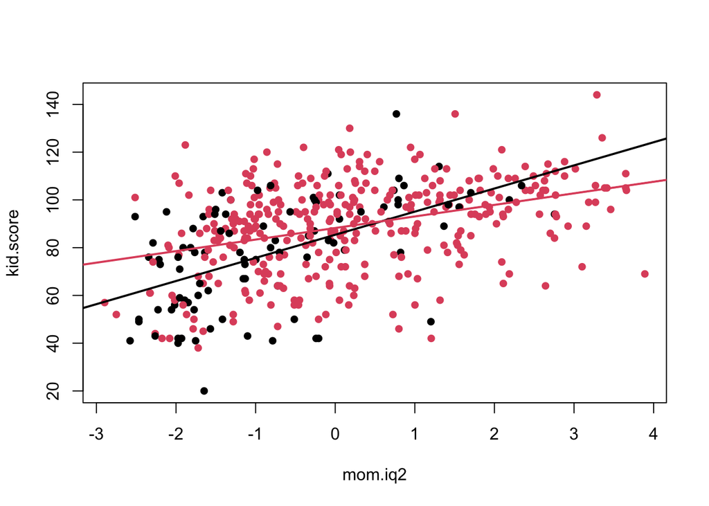

```r
plot(kid.score ~ mom.iq2,
     data = kidiq,
     col = (kidiq$mom.hs+1),
     pch = 16)

abline(coef(kidiq.lm5)[1], coef(kidiq.lm5)[3], lwd = 2) #Line for mom's who did NOT finish

abline(coef(kidiq.lm5)[1] + coef(kidiq.lm5)[2],
       coef(kidiq.lm5)[3] + coef(kidiq.lm5)[4], col = 2, lwd = 2) #Line for those that did finish HS
```

# **EXERCISES**

## 1. State Dataset Model

```r
statedata = read.csv("../datafiles/statedata.csv")
str(statedata) #Examining the data frame
```

```
## 'data.frame':    50 obs. of  9 variables:
##  $ State     : chr  "AL" "AK" "AZ" "AR" ...
##  $ Population: int  3615 365 2212 2110 21198 2541 3100 579 8277 4931 ...
##  $ Income    : int  3624 6315 4530 3378 5114 4884 5348 4809 4815 4091 ...
##  $ Illiteracy: num  2.1 1.5 1.8 1.9 1.1 0.7 1.1 0.9 1.3 2 ...
##  $ Life.Exp  : num  69 69.3 70.5 70.7 71.7 ...
##  $ Murder    : num  15.1 11.3 7.8 10.1 10.3 6.8 3.1 6.2 10.7 13.9 ...
##  $ HS.Grad   : num  41.3 66.7 58.1 39.9 62.6 63.9 56 54.6 52.6 40.6 ...
##  $ Frost     : int  20 152 15 65 20 166 139 103 11 60 ...
##  $ Area      : int  50708 566432 113417 51945 156361 103766 4862 1982 54090 58073 ...
```

```r
statedata.2 = statedata[ , -1] #Dropping the state column from the frame
str(statedata.2)
```

```
## 'data.frame':    50 obs. of  8 variables:
##  $ Population: int  3615 365 2212 2110 21198 2541 3100 579 8277 4931 ...
##  $ Income    : int  3624 6315 4530 3378 5114 4884 5348 4809 4815 4091 ...
##  $ Illiteracy: num  2.1 1.5 1.8 1.9 1.1 0.7 1.1 0.9 1.3 2 ...
##  $ Life.Exp  : num  69 69.3 70.5 70.7 71.7 ...
##  $ Murder    : num  15.1 11.3 7.8 10.1 10.3 6.8 3.1 6.2 10.7 13.9 ...
##  $ HS.Grad   : num  41.3 66.7 58.1 39.9 62.6 63.9 56 54.6 52.6 40.6 ...
##  $ Frost     : int  20 152 15 65 20 166 139 103 11 60 ...
##  $ Area      : int  50708 566432 113417 51945 156361 103766 4862 1982 54090 58073 ...
```

### 1.1 Constructing the models

```r
##Full Model
state.fullmod = lm(Life.Exp ~ ., data = statedata.2)
summary(state.fullmod)
```

```
##
## Call:
## lm(formula = Life.Exp ~ ., data = statedata.2)
##
## Residuals:
##      Min       1Q   Median       3Q      Max
## -1.48895 -0.51232 -0.02747  0.57002  1.49447
##
## Coefficients:
##               Estimate Std. Error t value Pr(>|t|)
## (Intercept)  7.094e+01  1.748e+00  40.586  < 2e-16 ***
## Population   5.180e-05  2.919e-05   1.775   0.0832 .
## Income      -2.180e-05  2.444e-04  -0.089   0.9293
## Illiteracy   3.382e-02  3.663e-01   0.092   0.9269
## Murder      -3.011e-01  4.662e-02  -6.459 8.68e-08 ***
## HS.Grad      4.893e-02  2.332e-02   2.098   0.0420 *
## Frost       -5.735e-03  3.143e-03  -1.825   0.0752 .
## Area        -7.383e-08  1.668e-06  -0.044   0.9649
## ---
## Signif. codes:  0 '***' 0.001 '**' 0.01 '*' 0.05 '.' 0.1 ' ' 1
##
## Residual standard error: 0.7448 on 42 degrees of freedom
## Multiple R-squared:  0.7362, Adjusted R-squared:  0.6922
## F-statistic: 16.74 on 7 and 42 DF,  p-value: 2.534e-10
```

```r
##Null Model (Intercept Only)
state.nullmod0 = lm(Life.Exp ~ 1, data = statedata.2)
summary(state.nullmod0)
```

```
##
## Call:
## lm(formula = Life.Exp ~ 1, data = statedata.2)
##
## Residuals:
##     Min      1Q  Median      3Q     Max
## -2.9186 -0.7611 -0.2036  1.0139  2.7214
##
## Coefficients:
##             Estimate Std. Error t value Pr(>|t|)
## (Intercept)  70.8786     0.1898   373.4   <2e-16 ***
## ---
## Signif. codes:  0 '***' 0.001 '**' 0.01 '*' 0.05 '.' 0.1 ' ' 1
##
## Residual standard error: 1.342 on 49 degrees of freedom
```

### 1.2 Stepwise Model Selection

```r
step(state.nullmod0, scope = formula(state.fullmod))
```

```
## Start:  AIC=30.44
## Life.Exp ~ 1
##
##              Df Sum of Sq    RSS     AIC
## + Murder      1    53.838 34.461 -14.609
## + Illiteracy  1    30.578 57.721  11.179
## + HS.Grad     1    29.931 58.368  11.737
## + Income      1    10.223 78.076  26.283
## + Frost       1     6.064 82.235  28.878
## <none>                    88.299  30.435
## + Area        1     1.017 87.282  31.856
## + Population  1     0.409 87.890  32.203
##
## Step:  AIC=-14.61
## Life.Exp ~ Murder
##
##              Df Sum of Sq    RSS     AIC
## + HS.Grad     1     4.691 29.770 -19.925
## + Population  1     4.016 30.445 -18.805
## + Frost       1     3.135 31.327 -17.378
## + Income      1     2.405 32.057 -16.226
## <none>                    34.461 -14.609
## + Area        1     0.470 33.992 -13.295
## + Illiteracy  1     0.273 34.188 -13.007
## - Murder      1    53.838 88.299  30.435
##
## Step:  AIC=-19.93
## Life.Exp ~ Murder + HS.Grad
##
##              Df Sum of Sq    RSS     AIC
## + Frost       1    4.3987 25.372 -25.920
## + Population  1    3.3405 26.430 -23.877
## <none>                    29.770 -19.925
## + Illiteracy  1    0.4419 29.328 -18.673
## + Area        1    0.2775 29.493 -18.394
## + Income      1    0.1022 29.668 -18.097
## - HS.Grad     1    4.6910 34.461 -14.609
## - Murder      1   28.5974 58.368  11.737
##
## Step:  AIC=-25.92
```

[output cut: 9 more lines]

```
## - HS.Grad     1     5.955 31.327 -17.378
## - Murder      1    32.756 58.128  13.531
##
## Step:  AIC=-28.16
## Life.Exp ~ Murder + HS.Grad + Frost + Population
##
##              Df Sum of Sq    RSS     AIC
## <none>                    23.308 -28.161
## + Income      1     0.006 23.302 -26.174
## + Illiteracy  1     0.004 23.304 -26.170
## + Area        1     0.001 23.307 -26.163
## - Population  1     2.064 25.372 -25.920
## - Frost       1     3.122 26.430 -23.877
## - HS.Grad     1     5.112 28.420 -20.246
## - Murder      1    34.816 58.124  15.528
```

```
##
## Call:
## lm(formula = Life.Exp ~ Murder + HS.Grad + Frost + Population,
##     data = statedata.2)
##
## Coefficients:
## (Intercept)       Murder      HS.Grad        Frost   Population
##   7.103e+01   -3.001e-01    4.658e-02   -5.943e-03    5.014e-05
```

### 1.3 Final Model Descriptions and AIC

- The final model is life expectancy as a function of murder, high school graduation, frost, and population **(Life.Exp ~ Murder + HS.Grad + Frost + Population)**. The AIC score is **-28.16** which is the lowest of the model outputs from the stepwise regression.

### 1.4a Model Summary

```r
state.finalmod = lm(Life.Exp ~ Murder + HS.Grad + Frost + Population, data = statedata.2)
summary(state.finalmod)
```

```
##
## Call:
## lm(formula = Life.Exp ~ Murder + HS.Grad + Frost + Population,
##     data = statedata.2)
##
## Residuals:
##      Min       1Q   Median       3Q      Max
## -1.47095 -0.53464 -0.03701  0.57621  1.50683
##
## Coefficients:
##               Estimate Std. Error t value Pr(>|t|)
## (Intercept)  7.103e+01  9.529e-01  74.542  < 2e-16 ***
## Murder      -3.001e-01  3.661e-02  -8.199 1.77e-10 ***
## HS.Grad      4.658e-02  1.483e-02   3.142  0.00297 **
## Frost       -5.943e-03  2.421e-03  -2.455  0.01802 *
## Population   5.014e-05  2.512e-05   1.996  0.05201 .
## ---
## Signif. codes:  0 '***' 0.001 '**' 0.01 '*' 0.05 '.' 0.1 ' ' 1
##
## Residual standard error: 0.7197 on 45 degrees of freedom
## Multiple R-squared:  0.736,  Adjusted R-squared:  0.7126
## F-statistic: 31.37 on 4 and 45 DF,  p-value: 1.696e-12
```

### 1.4b Model Summary Description

- The *F*-statistic is large at, **31.37**, and the *p*-value is extremely small, **1.696e-12**, which is less than our critical threshold of 0.05. The adjusted-$r^{2}$ statistic is **0.7126** which means approximately 71% of the variance in the data can be explained by the model. Given each of these metrics it appears that our final model fits well.

### 1.5a Prediction of Life Expectancy in Utah for 2009.

```r
#Creating a new data frame for Utah with:
#Population - 2,785,000
#HS Graduation - 75%
#Murder Rate - 1.3 per 100,000

new.utah = statedata.2[44, ] #isolate the Utah row from the statedata.2 frame
new.utah[1] = 2785 #change to population
new.utah[5:6] = c(1.3, 75) #change to murder rate and high school graduation

utah.pred = predict(state.finalmod, int = "prediction", level = 0.95, newdata = new.utah) #Utah prediction with a 95% confidence interval using the new.utah data frame

utah.pred
```

```
##         fit     lwr      upr
## 44 73.45601 71.8809 75.03112
```

### 1.5b Prediction of Life Expectancy in Utah for 2009 Description

- Based on our final model, it predicts that the life expectancy for people in Utah is approximately **73.5** with the lower portion of the prediction interval being 71.9 and the upper portion being 75.0.

### 1.6a Prediction of Life Expectancy in California for 2009

```r
#Creating a new data frame for California with:
#Population - 36,962,000
#HS Graduation - 68.3%
#Murder Rate - 5.3 per 100,000

new.cali = statedata.2[5, ] #isolate the California row from the statedata.2 frame
new.cali[1] = 36962 #change to population
new.cali[5:6] = c(5.3, 68.3) #change to murder rate and high school graduation

cali.pred = predict(state.finalmod, int = "prediction", level = 0.95, newdata = new.cali) #California prediction with a 95% prediction interval with the new values

cali.pred
```

```
##        fit      lwr      upr
## 5 74.35232 72.11398 76.59065
```

### 1.6b Prediction of Life Expectancy in California for 2009

- Based on our final model, it predicts that the life expectancy for people in California is approximately **74.4** with the lower portion of the prediction interval being 72.1 and the upper portion being 76.6.

## 2. Body Temperature Model

```r
##Reading in and adjusting the data

normtemp = read.csv("../datafiles/normtemp.csv")
normtemp$sex = factor(normtemp$sex, labels = c("Male", "Female")) #change 1 and 2 to male and female
```

### 2.1 Pearson’s Correlation Test

```r
cor.test(normtemp$weight, normtemp$temp) #Follows x, y format
```

```
##
##  Pearson's product-moment correlation
##
## data:  normtemp$weight and normtemp$temp
## t = 2.9668, df = 128, p-value = 0.003591
## alternative hypothesis: true correlation is not equal to 0
## 95 percent confidence interval:
##  0.08519113 0.40802170
## sample estimates:
##       cor
## 0.2536564
```

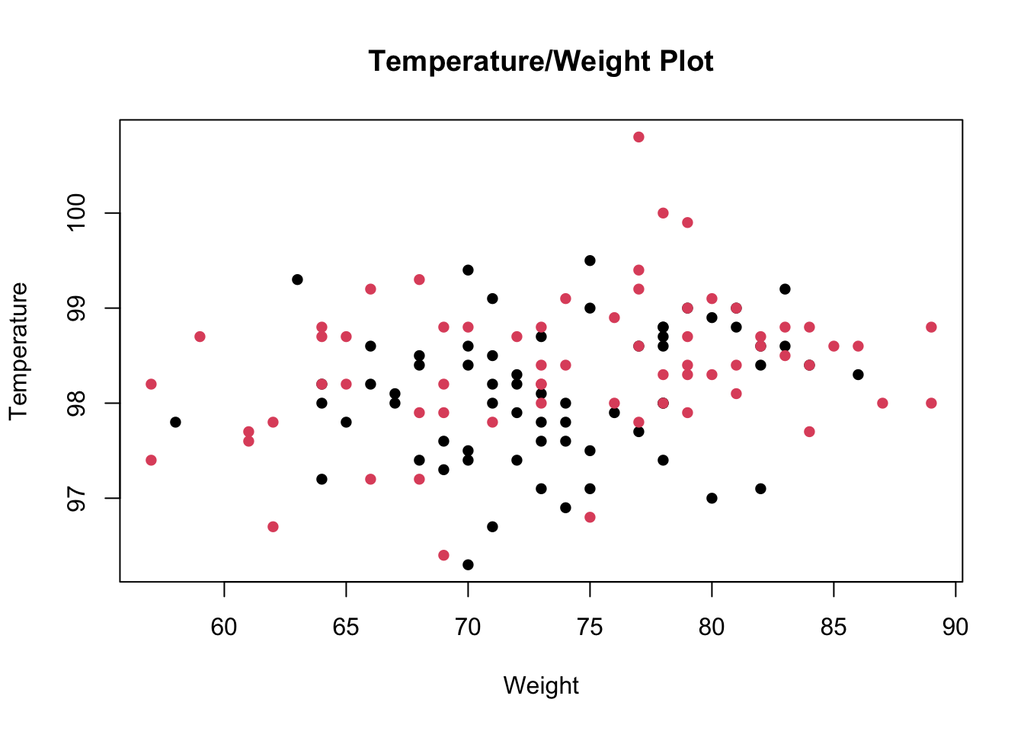

```r
##To visualize the data

plot(normtemp$weight, normtemp$temp,
     col = normtemp$sex,
     pch = 16,
     xlab = "Weight",
     ylab = "Temperature",
     main = "Temperature/Weight Plot")
```

### 2.2 Building a Model for Temperature as a Function of Weight and Sex

```r
temp.lm.full = lm(temp ~ weight + sex, data = normtemp)
summary(temp.lm.full)
```

```
##
## Call:
## lm(formula = temp ~ weight + sex, data = normtemp)
##
## Residuals:
##      Min       1Q   Median       3Q      Max
## -1.86363 -0.45624  0.01841  0.47366  2.33424
##
## Coefficients:
##              Estimate Std. Error t value Pr(>|t|)
## (Intercept) 96.250814   0.648717 148.371  < 2e-16 ***
## weight       0.025267   0.008762   2.884  0.00462 **
## sexFemale    0.269406   0.123277   2.185  0.03070 *
## ---
## Signif. codes:  0 '***' 0.001 '**' 0.01 '*' 0.05 '.' 0.1 ' ' 1
##
## Residual standard error: 0.7017 on 127 degrees of freedom
## Multiple R-squared:  0.09825,    Adjusted R-squared:  0.08405
## F-statistic: 6.919 on 2 and 127 DF,  p-value: 0.001406
```

### 2.3 Goodness-of-Fit for the Model

- The *F*-statistic is not very large at **6.919**, however, the *p*-value is statistically significant at **0.001406**. The $r^{2}$ is approximately 0.08 which indicates that only 8% of the variance in the data is explained by our model. Despite the statistically significant *p*-value, I would hesitate to call this model a good fit.

### 2.4 Coefficient Interpretation

- The first coefficient is approximately **96.25** and is the intercept. This means for a male of with a weight of zero, their body temperature is 96.25 degrees. This isn’t really useful in explaining our model as we know with someone of a weight of zero does not exist and therefore will not have a weight and temperature.
- The second coefficient is approximately **0.025** and it is the slope for a weight increase with all other variables fixed. Therefore for a weight increase of one we expect temperature to rise by 0.025.
- The third coefficient is approximately **0.269** and is the expected increase in temperature for a female, relative to males. This is a dummy offset as there is no interaction in the model.

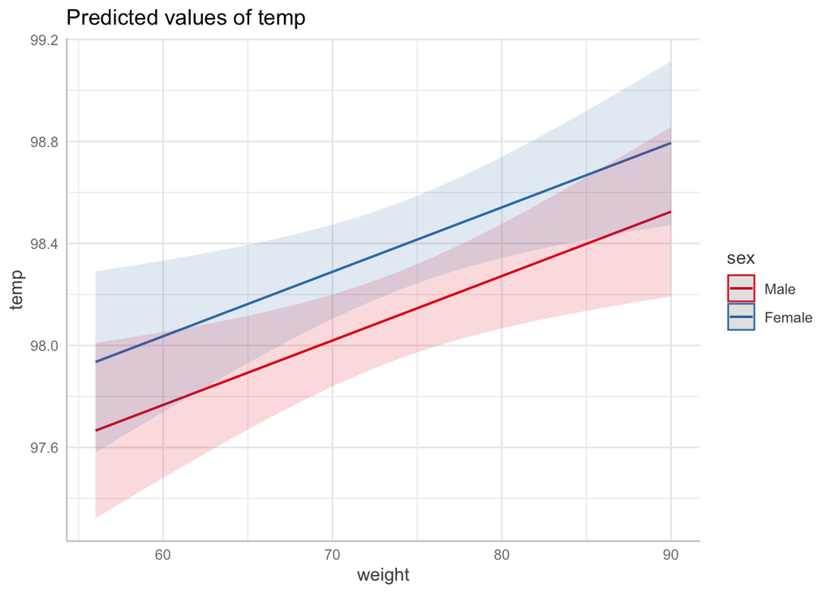

```r
##Help to visualize the temperature data
library(ggeffects)
temp.lm.full.effects = ggpredict(temp.lm.full, terms = c("weight", "sex"))
plot(temp.lm.full.effects)
```

### 2.5a Subset Model versus Full Model ANOVA

```r
temp.lm.sub.weight = lm(temp ~ weight, data = normtemp)
summary(temp.lm.sub.weight)
```

```
##
## Call:
## lm(formula = temp ~ weight, data = normtemp)
##
## Residuals:
##      Min       1Q   Median       3Q      Max
## -1.85017 -0.39999  0.01033  0.43915  2.46549
##
## Coefficients:
##              Estimate Std. Error t value Pr(>|t|)
## (Intercept) 96.306754   0.657703 146.429  < 2e-16 ***
## weight       0.026335   0.008876   2.967  0.00359 **
## ---
## Signif. codes:  0 '***' 0.001 '**' 0.01 '*' 0.05 '.' 0.1 ' ' 1
##
## Residual standard error: 0.712 on 128 degrees of freedom
## Multiple R-squared:  0.06434,    Adjusted R-squared:  0.05703
## F-statistic: 8.802 on 1 and 128 DF,  p-value: 0.003591
```

```r
anova(temp.lm.full, temp.lm.sub.weight)
```

```
## Analysis of Variance Table
##
## Model 1: temp ~ weight + sex
## Model 2: temp ~ weight
##   Res.Df    RSS Df Sum of Sq      F Pr(>F)
## 1    127 62.532
## 2    128 64.883 -1   -2.3515 4.7758 0.0307 *
## ---
## Signif. codes:  0 '***' 0.001 '**' 0.01 '*' 0.05 '.' 0.1 ' ' 1
```

### 2.5b Subset Model versus Full Model ANOVA Discussion

- The *F*-statistic for this comparison is **4.776** and the *p*-value is **0.031** which indicates that the full model is slightly better than the subset. Given this *p*-value we reject the null hypothesis that the subset model or simple model is better.